# Practical Machine Learning-Prediction Assignment Writeup

Dr.Govind Nidigattu

June 28, 2016

The objective and goal of this project is to predict the manner in which they performed the exercise and machine learning classification of accelerometers data on the belt, forearm, arm, and dumbell of 6 participants.In training data “classe” is the outcome variable in the training set using predictor variables to predict 20 different test cases.The data for this project come from this source is: http://groupware.les.inf.puc-rio.br/har.

The “classe” variable which classifies the correct and incorrect outcomes of A, B, C, D, and E categories. Coursera project writeup describes the model cross validation and expected out of sample error rate. Models applied successfully to predict all 20 different test cases on the Coursera website.

This project work partially submitted to the Coursera for the course “Practical Machine Learning” by Jeff Leek, PhD, Professor at Johns Hopkins University, Bloomberg School of Public Health.

```r
# The training and testing datasets for this project are available here below web resources
# https://d396qusza40orc.cloudfront.net/predmachlearn/pml-training.csv
# https://d396qusza40orc.cloudfront.net/predmachlearn/pml-testing.csv
```

```r
library(AppliedPredictiveModeling)
library(rpart)
library(ElemStatLearn)
library(pgmm)
library(caret)
library(e1071)
library(gbm)
library(lubridate)
library(plyr)
library(elasticnet)
library(C50)
library(car)
```

```r
## Removing NA values from training data
training1 <- read.csv("D://coursera//Practical Machine Learning//training.csv", header=T)
noNAtraining <- training1[ , colSums(is.na(training1)) == 0]
dim(noNAtraining)
```

```
## [1] 19622    93
```

```r
## Removing Variables with user related details by step by step
removetraining<-noNAtraining[,-c(1:7)]
removetraining1<-removetraining[,-c(5:13)]
removetraining2<-removetraining1[,-c(27:32)]
removetraining3<-removetraining2[,-c(30:39)]
removetraining4<-removetraining3[,-c(42:50)]
dim(removetraining4)
```

```
## [1] 19622    52
```

```r
# Removing highly correlated variables from training data
removetraining4.nonzerovar <- removetraining4
corrMatrix <- cor(na.omit(removetraining4.nonzerovar[sapply(removetraining4.nonzerovar, is.numeric)]))
dim(corrMatrix)
```

```
## [1] 51 51
```

Preprocessing of NA values and user related information has been done for both the testing and training datasets.Removed the variables that have extremely low variance and highly correlated.

```r
training <- read.csv("D://coursera//Practical Machine Learning//pmlmodeling//training.csv", header=T)
testing <- read.csv("D://coursera//Practical Machine Learning//pmlmodeling//testing.csv", header=T)
```

```r
#Data Partitioning and Prediction Process
library(caret)
trainingfinal <- training
inTrain<-createDataPartition(y=trainingfinal$classe, p=0.7,list = FALSE)
train<-trainingfinal[inTrain,]
test<-trainingfinal[-inTrain,]
```

```r
# Relative weights function
relweights <- function(fit,...){
  R <- cor(fit$model)
  nvar <- ncol(R)
  rxx <- R[2:nvar, 2:nvar]
  rxy <- R[2:nvar, 1]
  svd <- eigen(rxx)
  evec <- svd$vectors
  ev <- svd$values
  delta <- diag(sqrt(ev))
  lambda <- evec %*% delta %*% t(evec)
  lambdasq <- lambda ^ 2
  beta <- solve(lambda) %*% rxy
  rsquare <- colSums(beta ^ 2)
  rawwgt <- lambdasq %*% beta ^ 2
  import <- (rawwgt / rsquare) * 100
  lbls <- names(fit$model[2:nvar])
  rownames(import) <- lbls
  colnames(import) <- "Weights"
  barplot(t(import),names.arg=lbls,
          ylab="% of R-Square",
          xlab="Predictor Variables",
          main="Relative Importance of Predictor Variables",
          sub=paste("R-Square=", round(rsquare, digits=3)),
          ...)
  return(import)
  }
```

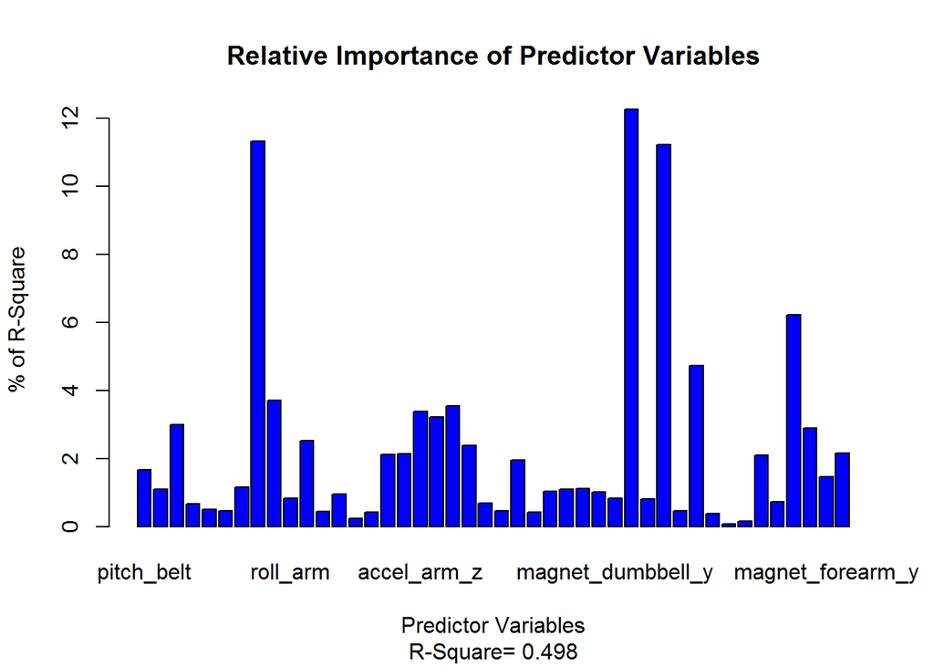

```
##                        Weights
## pitch_belt           1.6688839
## yaw_belt             1.0955564
## total_accel_belt     2.9897370
## gyros_belt_x         0.6669480
## gyros_belt_y         0.4989691
## gyros_belt_z         0.4588752
## magnet_belt_x        1.1532906
## magnet_belt_y       11.3181850
## magnet_belt_z        3.7154563
## roll_arm             0.8383242
## pitch_arm            2.5258409
## yaw_arm              0.4414682
## total_accel_arm      0.9451169
## gyros_arm_y          0.2384907
## gyros_arm_z          0.4142603
## accel_arm_x          2.1187225
## accel_arm_y          2.1372336
## accel_arm_z          3.3813379
## magnet_arm_x         3.2271041
## magnet_arm_y         3.5409904
## magnet_arm_z         2.3722092
## roll_dumbbell        0.6841214
## pitch_dumbbell       0.4607607
## yaw_dumbbell         1.9470288
## gyros_dumbbell_y     0.4220980
## accel_dumbbell_x     1.0258863
## accel_dumbbell_y     1.0910992
## accel_dumbbell_z     1.1102230
## magnet_dumbbell_x    1.0127591
## magnet_dumbbell_y    0.8220390
## magnet_dumbbell_z   12.2589816
## roll_forearm         0.8123303
## pitch_forearm       11.2184124
## yaw_forearm          0.4558657
## total_accel_forearm  4.7259294
## gyros_forearm_x      0.3825542
## gyros_forearm_y      0.0835612
## gyros_forearm_z      0.1659633
## accel_forearm_x      2.1017370
## accel_forearm_y      0.7186249
## accel_forearm_z      6.2238297
## magnet_forearm_x     2.8959427
## magnet_forearm_y     1.4679600
## magnet_forearm_z     2.1652916
```

```r
training <- read.csv("D://coursera//Practical Machine Learning//pmlmodeling//training.csv", header=T)
dtrain <- training
dtrain <- data.frame(dtrain)
dtrain <- data.frame(sapply(dtrain,as.numeric))
fit <- lm(classe ~ ., data=dtrain)
relweights(fit,col="blue")
```

Ralative importance of predictor variables based on weights are magnet_belt_y(11.3181850), magnet_dumbbell_z(12.2589816),pitch_forearm(11.2184124), pitch_forearm(11.2184124), accel_forearm_z(6.2238297), total_accel_forearm (4.7259294),accel_arm_z(3.3813379), magnet_arm_x(3.2271041) and magnet_arm_y(3.5409904).

```r
set.seed(3141592)
fitModel <- train(classe~.,data=train,method="rf",trControl=trainControl(method="cv",number=10),
                  prox=TRUE,
                  verbose=TRUE,
                  allowParallel=TRUE)
predictions <- predict(fitModel, newdata=test)
confusionMat <- confusionMatrix(predictions, test$classe)
confusionMat
```

```
## Confusion Matrix and Statistics
##
##           Reference
## Prediction    A    B    C    D    E
##          A 1671    6    0    0    0
##          B    3 1132    7    0    0
##          C    0    1 1016   13    3
##          D    0    0    3  951    1
##          E    0    0    0    0 1078
##
## Overall Statistics
##
##                Accuracy : 0.9937
##                  95% CI : (0.9913, 0.9956)
##     No Information Rate : 0.2845
##     P-Value [Acc > NIR] : < 2.2e-16
##
##                   Kappa : 0.992
##  Mcnemar's Test P-Value : NA
##
## Statistics by Class:
##
##                      Class: A Class: B Class: C Class: D Class: E
## Sensitivity            0.9982   0.9939   0.9903   0.9865   0.9963
## Specificity            0.9986   0.9979   0.9965   0.9992   1.0000
## Pos Pred Value         0.9964   0.9912   0.9835   0.9958   1.0000
## Neg Pred Value         0.9993   0.9985   0.9979   0.9974   0.9992
## Prevalence             0.2845   0.1935   0.1743   0.1638   0.1839
## Detection Rate         0.2839   0.1924   0.1726   0.1616   0.1832
## Detection Prevalence   0.2850   0.1941   0.1755   0.1623   0.1832
## Balanced Accuracy      0.9984   0.9959   0.9934   0.9929   0.9982
```

```r
#Training and test set dimensions
dim(train)
```

```
## [1] 13737    45
```

```r
dim(test)
```

```
## [1] 5885   45
```

```r
# Classification by c50 algorithm
library(C50)
C50.model0 <- C5.0(classe ~ ., data = training,rules=TRUE)
test.C50.model0 <- predict.C5.0(C50.model0, testing, type = "class")
test.C50.model0.df <- as.data.frame(test.C50.model0)
names(test.C50.model0.df)
```

```
## [1] "test.C50.model0"
```

```r
test.C50.model0.df$id <- testing$id
print(test.C50.model0.df)
```

```
##    test.C50.model0
## 1                B
## 2                A
## 3                B
## 4                A
## 5                A
## 6                E
## 7                D
## 8                B
## 9                A
## 10               A
## 11               B
## 12               C
## 13               B
## 14               A
## 15               A
## 16               E
## 17               A
## 18               B
## 19               B
## 20               B
```

```r
# Classification by random forest
library(randomForest)
set.seed(1234)
fit.forest <- randomForest(classe~., data=training,
                           na.action=na.roughfix,
                           importance=TRUE)
fit.forest
```

```
##
## Call:
##  randomForest(formula = classe ~ ., data = training, importance = TRUE,      na.action = na.roughfix)
##                Type of random forest: classification
##                      Number of trees: 500
## No. of variables tried at each split: 6
##
##         OOB estimate of  error rate: 0.33%
## Confusion matrix:
##      A    B    C    D    E  class.error
## A 5577    2    0    0    1 0.0005376344
## B   12 3781    4    0    0 0.0042138530
## C    0   14 3406    2    0 0.0046756283
## D    0    0   19 3195    2 0.0065298507
## E    0    0    2    6 3599 0.0022179096
```

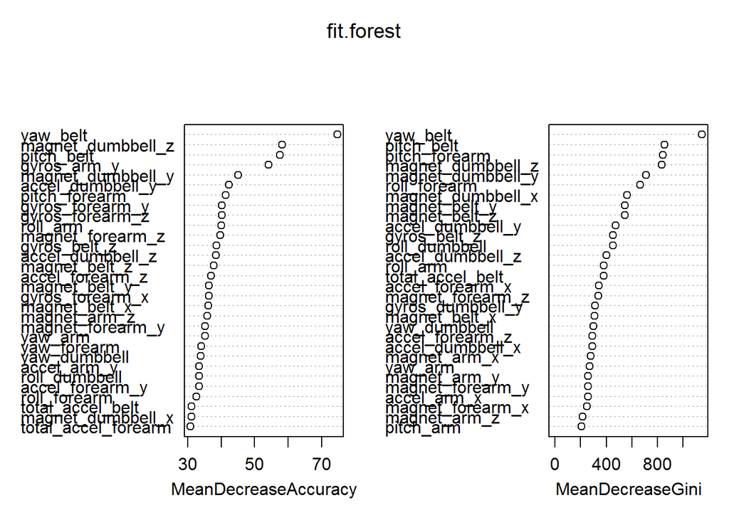

```r
varImpPlot(fit.forest)
```

```r
importance(fit.forest, type=2)
```

```
##                     MeanDecreaseGini
## pitch_belt                 854.22231
## yaw_belt                  1147.34575
## total_accel_belt           380.14744
## gyros_belt_x               136.64078
## gyros_belt_y               158.35832
## gyros_belt_z               453.76949
## magnet_belt_x              310.15020
## magnet_belt_y              547.11476
## magnet_belt_z              544.22635
## roll_arm                   381.63257
## pitch_arm                  207.87094
## yaw_arm                    272.71446
## total_accel_arm            120.82378
## gyros_arm_y                184.56832
## gyros_arm_z                 75.95523
## accel_arm_x                256.31846
## accel_arm_y                192.06775
## accel_arm_z                156.12140
## magnet_arm_x               280.76086
## magnet_arm_y               260.03450
## magnet_arm_z               214.47622
## roll_dumbbell              451.99303
## pitch_dumbbell             204.56764
## yaw_dumbbell               300.02799
## gyros_dumbbell_y           311.10757
## accel_dumbbell_x           291.46112
## accel_dumbbell_y           472.81049
## accel_dumbbell_z           403.31147
## magnet_dumbbell_x          563.55914
## magnet_dumbbell_y          710.62236
## magnet_dumbbell_z          831.96917
## roll_forearm               662.67678
## pitch_forearm              842.83911
## yaw_forearm                196.05915
## total_accel_forearm        134.88515
## gyros_forearm_x             96.12649
## gyros_forearm_y            152.92513
## gyros_forearm_z             97.75673
## accel_forearm_x            342.02733
## accel_forearm_y            173.48740
## accel_forearm_z            292.54912
## magnet_forearm_x           248.11453
## magnet_forearm_y           259.67897
## magnet_forearm_z           336.50295
```

```r
forest.pred <- predict(fit.forest, newdata=testing)
forest.pred
```

```
##  1  2  3  4  5  6  7  8  9 10 11 12 13 14 15 16 17 18 19 20
##  B  A  B  A  A  E  D  B  A  A  B  C  B  A  E  E  A  B  B  B
## Levels: A B C D E
```

```r
# Classification by SVM
library(e1071)
set.seed(1234)
df.train <- training
df.validate <- testing
table(df.train$classe)
```

```
##
##    A    B    C    D    E
## 5580 3797 3422 3216 3607
```

```r
table(df.validate$classe)
```

```
## < table of extent 0 >
```

```r
fit.svm <- svm(classe~., data=df.train)
fit.svm
```

```
##
## Call:
## svm(formula = classe ~ ., data = df.train)
##
##
## Parameters:
##    SVM-Type:  C-classification
##  SVM-Kernel:  radial
##        cost:  1
##       gamma:  0.02272727
##
## Number of Support Vectors:  8038
```

```r
svm.pred <- predict(fit.svm, na.omit(df.validate))
svm.pred
```

```
##  1  2  3  4  5  6  7  8  9 10 11 12 13 14 15 16 17 18 19 20
##  B  A  B  A  A  E  D  B  A  A  B  C  B  A  E  E  A  B  B  B
## Levels: A B C D E
```